# Visualizing Time Series Data in Python

#### Decompose time series data

We will now perform time series decomposition on multiple time series. We can achieve this by leveraging the Python `dict`ionary to store the results of each time series decomposition.

In this exercise, we will initialize an empty dictionary with a set of curly braces, `{}`, use a `for` loop to iterate through the columns of the DataFrame and apply time series decomposition to each time series. After each time series decomposition, we place the results in the dictionary by using the command `my_dict[key] = value`, where `my_dict` is our dictionary, `key` is the name of the column/time series, and `value` is the decomposition object of that time series.

```python
# Initialize dictionary
jobs_decomp = {}

# Get the names of each time series in the DataFrame
jobs_names = jobs.columns

# Run time series decomposition on each time series of the DataFrame
for ts in jobs_names:
    ts_decomposition = sm.tsa.seasonal_decompose(jobs[ts])
    jobs_decomp[ts] = ts_decomposition
```

We will now extract the `seasonality` component of `jobs_decomp` to visualize the seasonality in these time series. Note that before plotting, we will have to convert the dictionary of `seasonality` components into a DataFrame using the `pd.DataFrame.from_dict()` function.

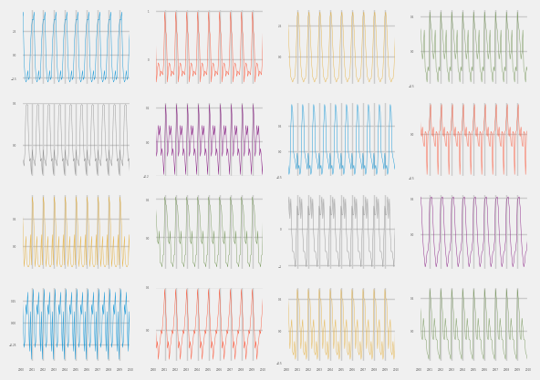

```python
jobs_seasonal = {}

# Extract the seasonal values for the decomposition of each time series
for ts in jobs_names:
    jobs_seasonal[ts] = jobs_decomp[ts].seasonal

# Create a DataFrame from the jobs_seasonal dictionary
seasonality_df = pd.DataFrame.from_dict(jobs_seasonal)

# Remove the label for the index
seasonality_df.index.name = None

# Create a faceted plot of the seasonality_df DataFrame
seasonality_df.plot(subplots=True,
                   layout=(4,4),
                   sharey=False,
                   fontsize=2,
                   linewidth=0.3,
                   legend=False)

# Show plot
plt.show()
```

Each time series in the jobs DataFrame have very different seasonality patterns!

#### Compute correlations between time series

In the previous exercise, we extracted the `seasonal` component of each time series in the `jobs` DataFrame and stored those results in new DataFrame called `seasonality_df`. In the context of jobs data, it can be interesting to compare seasonality behavior, as this may help uncover which job industries are the most similar or the most different.

This can be achieved by using the `seasonality_df` DataFrame and computing the correlation between each time series in the dataset. In this exercise, we will leverage what we have learned in Chapter 4 to compute and create a clustermap visualization of the correlations between time series in the `seasonality_df` DataFrame.

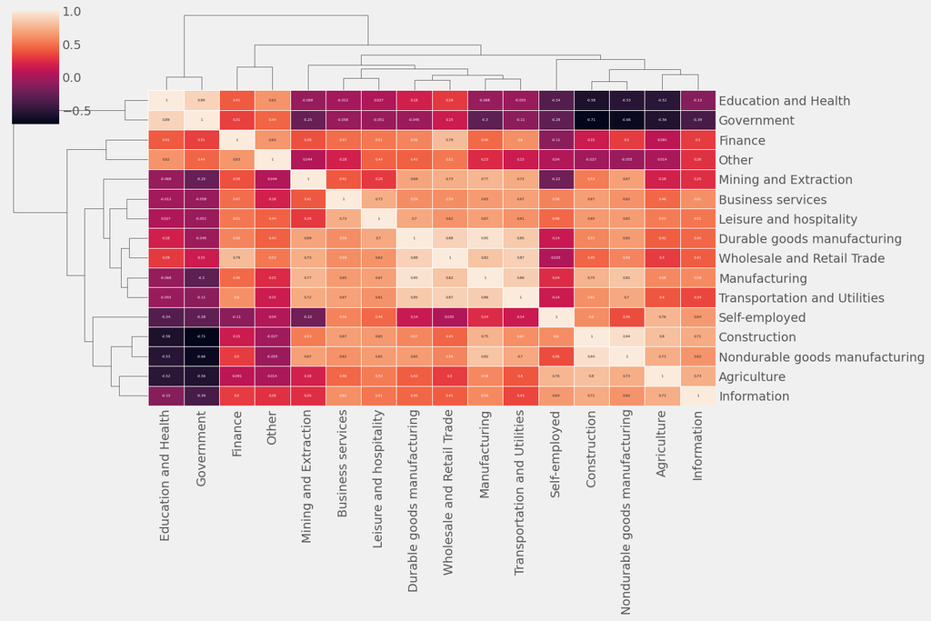

```python
# Get correlation matrix of the seasonality_df DataFrame
seasonality_corr = seasonality_df.corr(method='spearman')

# Customize the clustermap of the seasonality_corr correlation matrix
fig = sns.clustermap(seasonality_corr, annot=True, annot_kws={"size": 4}, linewidths=.4, figsize=(15, 10))
plt.setp(fig.ax_heatmap.yaxis.get_majorticklabels(), rotation=0)
plt.setp(fig.ax_heatmap.xaxis.get_majorticklabels(), rotation=90)
plt.show()
```